# MIDI-MT - Remote Control Panel Module

MIDI-MT Documentation in English

## Built-in remote control application

- Remote Control Panel module settings
- Authorization and other protective measures
- Configuration file
- Interface
- Remote Control API

Allows you to manage configured controls using a remote control panel. This is a built-in “**Web application**”, interaction with which occurs through a browser, as a result, use is possible on any operating system.

For the module to work, it is necessary to accept incoming requests; this requires setting up the “windows firewall”, as in the image below:

[figure not shown]

### Remote Control Panel module settings

- In the **Network Settings** group, selecting Network **Interface** will limit access to the control panel to the selected network only.
- The “**Port**” field specifies on which port to accept input requests; the default port number is `8888`.
- The **Connection Timeout** option specifies the time to wait for the connection in milliseconds.
- The **Wait Timeout** option specifies the time to wait for a client response in milliseconds.
- The checked item “**Use IPv6**” enables `IPv6` support for `WebSocket`, and the type of the selected network interface must also be `IPv6`.
- The “**Fast socket opening**” option allows you to minimize timings when receiving and transmitting data.
- The “**Address reuse**” item is used to disable `exclusive access` when accessing system sockets. Enabled by default.
- Selecting “**Client session logging level**” turns on or off the recording of debugging information about network exchange and commands to the general log file.

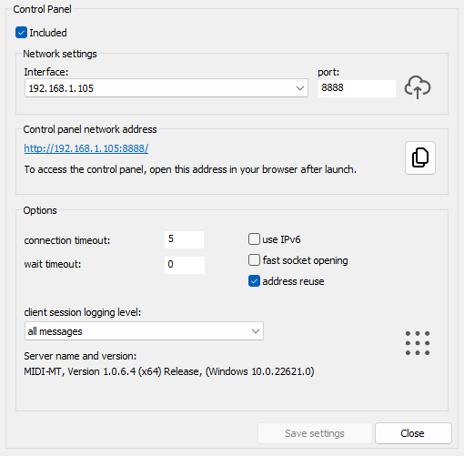

The “**Save Settings**” button will allow you to save the changes you have made in the current session. To save in a configuration file, after saving the session settings, you must use the “**Save settings**” button on the main screen of the “**Start**” dialog.

Any changes made using `MIDI Control Surface`, `control panels` and other `input devices` are immediately reflected on all connected control panels. For example, this can help control lighting fixtures with a team of operators. Also, when setting up sound in a studio, it is convenient to be able to regulate sound channels remotely, changing the sound level locally.

### Authorization and other protective measures

Authorization or other protective measures for access to the remote control panel are not provided; the solution is designed to work in a local network. If necessary, for access via the Internet, you can install any `HTTPS` front-end with `Web Socket` support, for example [`nginx`](https://nginx.org/en/docs/http/websocket.html).

#### Configuration file

It is also possible to edit the configuration file in any editor you are familiar with. The main section of the “**remote control panel**” module settings looks like this:

```yaml
    ...
    },
    "remote": {
        "enable": true,
        "port": 8888,
        "host": "192.168.22.1",
        "ua": "MIDI-MT, Version 1.0.x.x (xXX) Release, (Windows xx.x.xxxxx.x)",
        "tmreq": 5,
        "tmidle": 0,
        "loglevel": 4,
        "ipv6": false,
        "reuseaddr": true,
        "fastsock": false
    },
    "units":[ ...
    ... ]
```

#### Interface

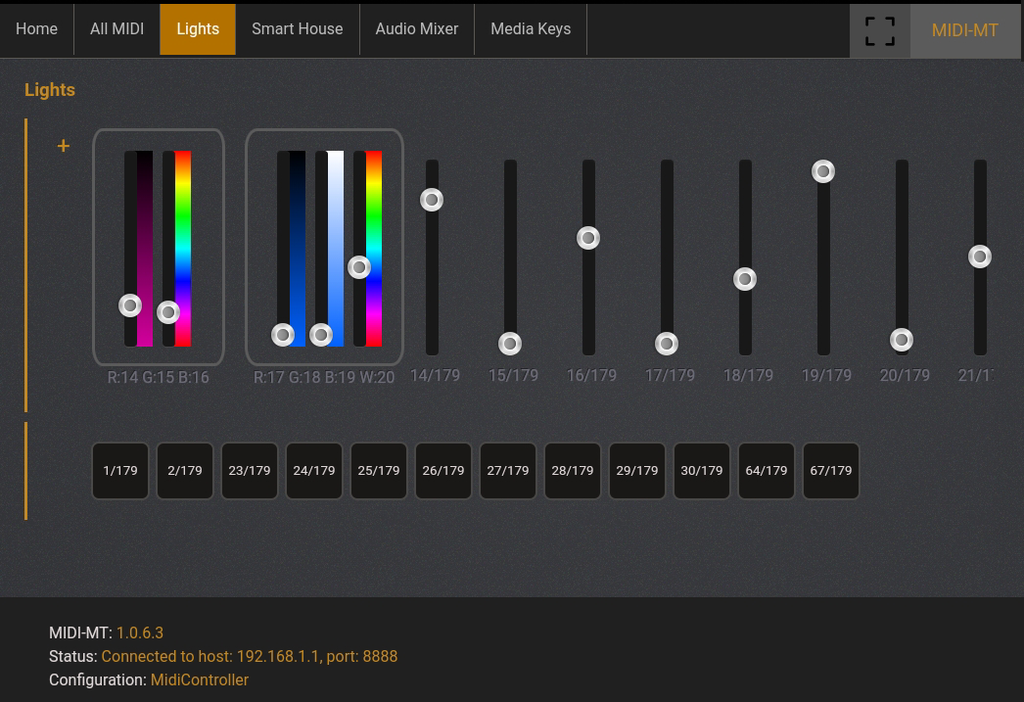